# Coursework Report

*N* removed NAs: 6

*N* removed <18: 25

**Correct typo age:** 22

*N* total clean: 137

| Group | *N* | *M*<sub>age</sub> | % green |
| --- | --- | --- | --- |
| Control | 68 | 20.56 | 51.96 |
| Experim | 69 | 20.23 | 37.68 |

| Gender | *N* | *M*<sub>age</sub> | % green |
| --- | --- | --- | --- |
| Female | 70 | 20.17 | 43.33 |
| Male | 44 | 20.75 | 46.97 |
| Other | 23 | 20.39 | 44.93 |

**Main analysis results**

**car:**  
χ<sup>2</sup>(1) = 2.11, *p* = .147

**cleaner:**  
χ<sup>2</sup>(1) = 7.07, *p* = .008

**dishwasher:**  
χ<sup>2</sup>(1) = 0.18, *p* = .673

[interactive chart not shown]

[figure not shown]

[interactive chart not shown]

# Coursework Report

Analysing Data, Spring 2020

# Methods

## Participants

The *M*<sub>age</sub> of participants is 20.39, with a *SD* of 1.72. The age range of participants is between 18-25. Table 1 below shows the descriptive statistics of the data set used.

Table 1 *Descriptive statistics by Gender*

[output not shown]

## Design

The design of this study is based on the existing experiment by Griskevicius & Tybur (2010). Because status motives are thought to encourage prosocial behaviour, the research question sets to find out if invoking status motives effect the participants decision to buy a green, environmentally friendly product over a non-green, less environmentally friendly product. It is expected that status motives will be related to the purchasing of green products.

Most variables in this experiment are factors; *gender* being measured as male, female, or other, the *condition* being either experimental or control, the presented *product* choice being between dishwasher, car, or cleaner, and the *category* choice being between either luxury or green. The *age* variable is measured as continuous, including possible ages 18 to 98.

The study was designed with between-subjects motive conditions: experimental and control. Participants placed in the ‘experimental’ condition took part in the status motive group, where they were asked to read a story to elicit feelings of status motive. If the participant is in the ‘control’ condition, it means the they were part of the control group, who read an alternative story designed to evoke similar levels of affect as the experimental group, but not status motive.

It is expected that, due to the high levels of status motives elicited in the experimental group, those participants would more frequently choose the green product over the non-green/luxury product on all three types (dishwasher, car or cleaner). It is predicted that the control group would more frequently choose luxury, non-green products than those in the experimental group across all three types of product. There is not expected to be any significance relating to age or gender. The results will be analysed for significance using chi-squared tests.

# Results

As seen in Table 2 and Figure.1, in the control condition participants were more likely to choose the green car (52% chose green, where 48% chose luxury). Table 2 and Figure.1 show the experimental group more frequently choosing the luxury car over the green car (with 62% choosing luxury, and 38% choosing green).

When choosing between cleaning products, the control condition was more likely to choose the green product (with 56% choosing green, and 44% choosing luxury). The largest difference in choice came from the cleaning product experimental group, where 67% of participants chose the luxury item, and 33% chose the green product (shown by Table 4 and Figure.3).

These results show that when status motives are present, participants tend to choose luxury non-green products instead of the green products.

Table 2: *Frequency of Selection by Car*

|  | luxury | green |
| --- | --- | --- |
| control | 33 | 35 |
| experimental | 43 | 26 |

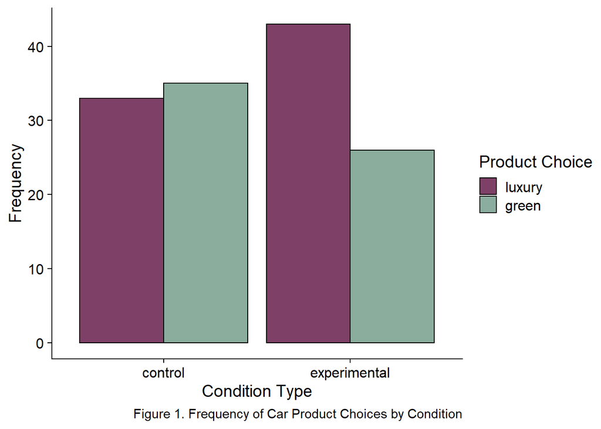

Table 3: *Frequency of Selection by Dishwasher*

|  | luxury | green |
| --- | --- | --- |
| control | 35 | 33 |
| experimental | 39 | 30 |

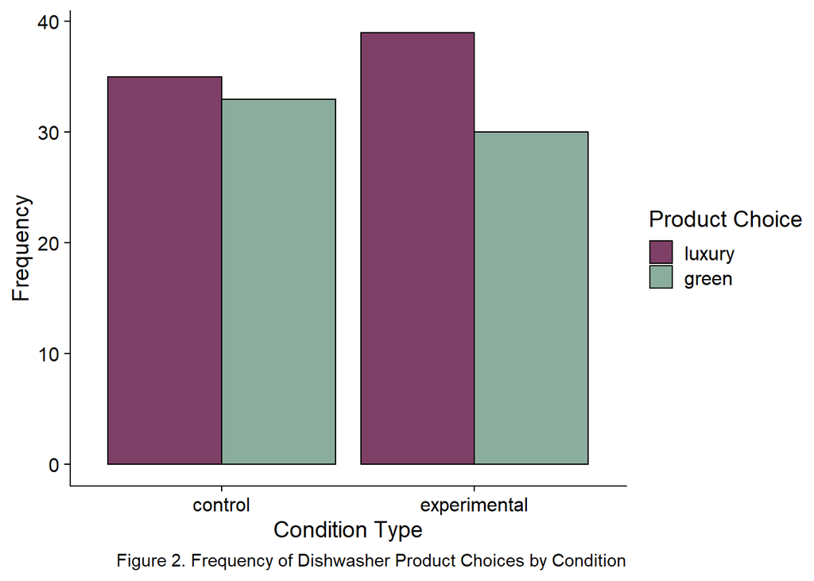

Table 4: *Frequency of Selection by Cleaning Product*

|  | luxury | green |
| --- | --- | --- |
| control | 30 | 38 |
| experimental | 46 | 22 |

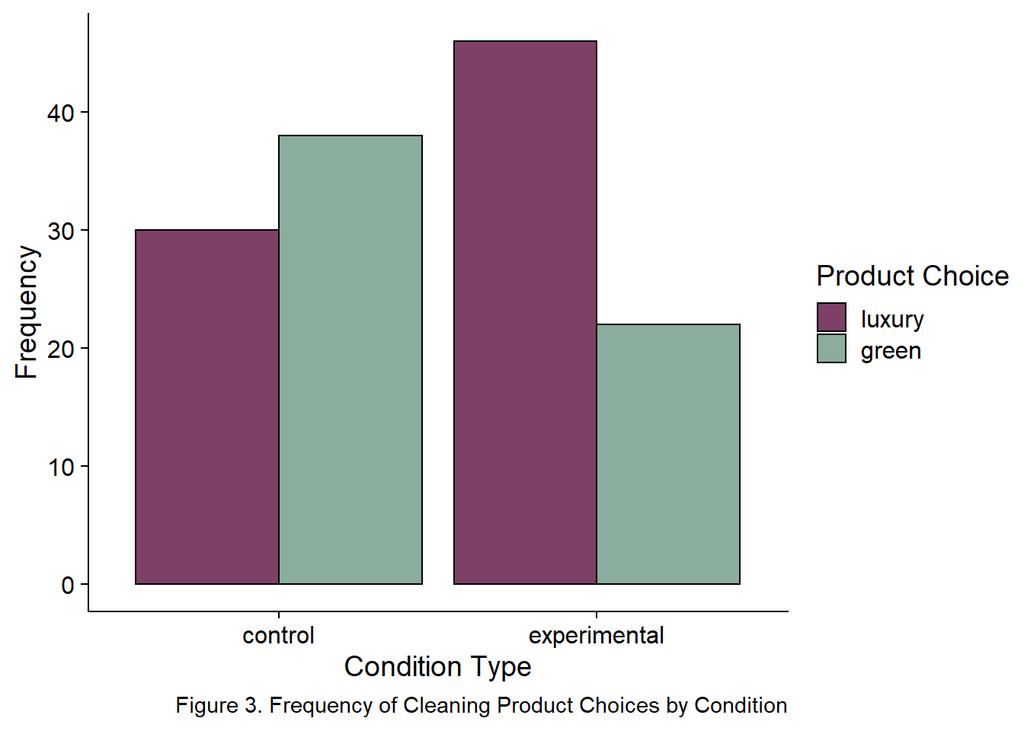

Using the significance level α0.05, chi-squared analysis revealed no significant association between status motives and the choice of car product, *χ*<sup>2</sup>(1) = 2.11, *p* = 0.147. This means there is not enough evidence for the results to be considered as causational, and thus suggests we should accept the null hypothesis in this instance.

In the dishwasher category, there was no support for any relationship between status motives and choice of dishwasher, where *χ*<sup>2</sup>(1) = 0.18, *p* = 0.673. The null hypothesis must therefore be accepted for the selection of dishwasher type.

# Discussion

The research question set to find out if invoking status motives effects the participants decision to buy a green product over a more luxurious, non-green product. It was expected that status motives would be significantly related to an increase in the purchasing of green products due to an increase in prosociability. However, the general pattern of results showed the experimental groups choosing luxury products more frequently across all types of products. In contrast, the control group appear to choose between green or non-green luxury products fairly evenly across all categories of items.  
The only significant result came from the cleaning product experiment, demonstrating a relationship between status motives and the purchasing of green products, in the opposite way of what was expected. The significant relationship was found to be that when exposed to a story which heightened status motives, the participants more frequently chose the more luxurious, non-green cleaning product. When invoking status motives in participants choosing between cars and dishwashers, there was *no* evidence for a significant relationship between status and the purchasing of green products.

The results in this study differ from other existing research in similar fields. Griskevicius & Tybur (2010) found significant results when running an identical study, reporting the important influence of status motives on the increased purchasing of environmentally friendly products. Across all product purchasing, it was found that those in the experimental condition more frequently purchased green products than luxury products (Griskevicius & Tybur, 2010). However, the results gathered from experiment in this report follow a similar pattern to what Godoy et al (2007) found when studying individual consumption and status signalling. Godoy’s (2007) research provides a perspective that when increasing social status, it produces an increased desire for more luxurious goods, showing support for the results found in the cleaning category of this experiment, as well as the potentiality for explaining the lack of support for purchasing green-products by the experimental category overall.

This experiment highlights the necessity in further exploration of the link between status motives and the purchasing of green, environmentally friendly products. There seems to be a gap in this specific area which hasn’t been filled with data rich sources or includes frequently conflicting evidence. In a meta-analysis by Joshi & Rahman (2015), there was no reports of status motives being studied for their effect on green product purchasing, meaning the area could benefit from study replications and further examination; since thus far it seems like a promising area to investigate.

Because this study disagrees with the findings of those such as Griskevicius & Tybur (2010), it would also be ideal to identify some alternative factors which may either encourage or discourage the purchasing of green products. For instance, Sadalla & Krull (1995) reported eco-friendly behaviour from participants when it was associated with being complimentary to a higher social status, i.e. being associated with wealth. It could therefore be speculated that because there was no price difference between green products and luxury products in this experiment, there was no significant relationship between the two. In future experiments it would therefore be useful to explore the effect of price difference on eco-friendly behaviour. This direction was examined by Griskevicius & Tybur (2010) in their second experiment, where it was reported that the influence of status motives were relative to the prices of the products. In addition to this, Joshi & Rahman (2015) reported environmental concern, functional attributes of green product, sense of responsibility, and altruism to be some of the main factors in influencing pro-environmental behaviour.

Since this experiment returned no significant causation between status motives and green product purchasing when examining cars or dishwashers, it is not possible to comment on how these factors have an effect in the wider context. However, the results of this experiment make it possible to build on research from Godoy et al (2007) and Sadalla & Krull (1995), to speculate the influence of social status motives in encouraging the purchasing of more expensive, luxurious goods. One direction future research could take would be to investigate the influence of increasing the participants feelings of wealth specifically and comparing which type of purchases are made.

Joshi & Rahman (2015) reported that most studies examining green product purchasing behaviour showed a weak relationship between attitude and actual purchase behaviour. When reviewing 53 articles focused on green product purchasing, Joshi & Rahman (2015) reported most studies struggling to identify the factors effecting behaviour. If this is considered to be the outcome of many studies attempting to identify the same thing, it may be that there is a problem in the way variables are measured, and therefore poses a question in the validity of these studies. One way to combat this would be post-trial questionnaires and feedback, asking for participants responses about how they felt when taking part in the experiment. For instance, asking each participant a number of questions about mood/thoughts/feelings after reading the control story, and the status motive story. It may also be possible to ask participants their thoughts after being debriefed; they might have some genuine answers to why they purchased the product they did - therefore providing directions for future research.

Ultimately, there are many different factors affecting the purchasing of green products, with up to 53 factors affecting purchase behaviour and up to 35 factors affecting product purchasing intentions (Joshi & Rahman, 2015). In context of the wider field of pro-environmental behaviour, these studies are important in establishing the motives for behaviour, so there can be an encouragement towards a more positive ecological future. Despite there being little significant evidence for status motives from this study alone, it still gives an important perspective on the behaviour of consumers and provides a larger data set for the basis of future research.

# References

Griskevicius, V. & Tybur, J.M. (2010). Going Green to Be Seen: Status, Reputation, and Conspicuous Conservation. *Journal of Personality and Social Psychology, 98*(3), 392-404.

Godoy, R., Reyes-Garcı´a, V., Leonard, W. R., Huanca, T., McDade, T., Vadez, V., & Tanner, S. (2007). Signaling by consumption in a native Amazonian society. *Evolution and Human Behavior, 28*, 124-134.

Sadalla, E. K., & Krull, J. L. (1995). Self-Presentational Barriers to Resource Conservation. *Environment and Behavior, 27*(3), 328–353.

Joshi, Y. & Rahman, Z. (2015). Factors Affecting Green Purchase Behaviour and Future Research Directions. *International Strategic Management Review, 3*(1-2), 128-143.